```r
library(tidyverse)
```

# STATS 306

## Problem set 8: Iteration and functional programming

Each problem is worth two to four points, depending on difficulty, for a total of 20.

*Note*: you do not need to use `install.packages()` in this notebook. You may assume that we have already installed all of the necessary packages when we run your code.

#### Problem 1 (2 pts.)

Write a function `meta_map(lv, lf)` which takes two list arguments of equal length: a list of double vectors `lv`, and a list of real-valued functions `lf`. `meta_map` should return a new list `ret` whose $i$-th entry `ret[[i]]` is a vector of type double which is the result mapping the $i$-th function `lf[[i]]` over the $i$-th vector `lv[[i]]`. For example:

```
{r}
> meta_map(list(1:2, 3:4), list(function(x) x + 1, function(x) x^2))
[[1]]
[1] 2 3

[[2]]
[1]  9 16
```

```r
meta_map = function(lv, lf) {
    ### BEGIN SOLUTION
    map2(lv, lf, map_dbl)
    ### END SOLUTION
}
```

```r
stopifnot(
    map2(meta_map(list(1:5, 10:15, 1:6 * pi), list(function(x) x + 1, function(x) x^3, sin)),
    list(1 + 1:5, (10:15)^3, 0), near) %>% unlist %>% all)

### BEGIN HIDDEN TESTS

meta_map_soln = function(lv, lf) {
    map2(lv, lf, map_dbl)
}
for (n in 0:10) {
    lv = list(rnorm(n = n))
    stopifnot(near(unlist(meta_map(lv, list(sin))),
                   unlist(meta_map_soln(lv, list(sin)))))
}
### END HIDDEN TESTS
```

#### Problem 2 (3 pts.)

Write a function `call_until(f, g)` which takes two function arguments `f` and `g` and does the following:

1. Repeatedly calls `f()` until `f` returns the same value three times in a row.
2. Calls `g()`:
   1. If `g` returns the same value that `f()` returned three times in a row in step one, then `call_until` returns this value.
   2. Otherwise, `call_until` goes back to step 1 and the process repeats.

```r
call_until = function(f, g) {
    ### BEGIN SOLUTION
    while (TRUE) {
        last = NA
        succ = 0
        while (succ < 2) {
            x = f()
            if (!is.na(last) && x == last) {
                succ = succ + 1
            } else {
                succ = 0
                last = x
            }
        }
        if (g() == last) {
            return(last)
        }
    }
    ### END SOLUTION
}
```

```r
i = 0
f = function() {
    i <<- i + 1
    i < 10
}
g = function() {
    TRUE
}
stopifnot(call_until(f, g))
stopifnot(i == 3)

i = 0
set.seed(1)
f = function() {
    i <<- i + 1
    sample(1:8, 1)
}
j = 0
g = function() {
    j <<- j + 1
    sample(1:5, 1)
}
stopifnot(call_until(f, g) == 5)
stopifnot(i == 137)
stopifnot(j == 2)

### BEGIN HIDDEN TESTS
call_until_sol = function(f, g) {
    while (TRUE) {
        last = NA
        succ = 0
        while (succ < 2) {
            x = f()
            if (!is.na(last) && x == last) {
                succ = succ + 1
            } else {
                succ = 0
                last = x
            }
        }
        if (g() == last) {
            return(last)
        }
    }
}
check = map(list(call_until, call_until_sol), function(q) {
    i = 0
    set.seed(20)
    f = function() {
        i <<- i + 1
        sample(1:10, 1)
    }
    j = 0
    g = function() {
        j <<- j + 1
        sample(1:10, 1)
    }
    list(q(f, g), i, j)
    })
stopifnot(all.equal(check[[1]], check[[2]]))
### END HIDDEN TESTS
```

#### Problem 3 (3 pts.)

Write a function called `r_cat` which can be passed to `reduce` to concatenate a list of vectors together. For example,

```
{r}
reduce(list(1:10, 11:20, 21:100), r_cat, .init = NULL)
```

should return a vector equal to `1:100`.

```r
r_cat = function(x, y) {
    ### BEGIN SOLUTION
    c(x, y)
    ### END SOLUTION
}
```

```r
stopifnot(reduce(list(1:10, 11:20, 21:100), r_cat, .init = NULL) == 1:100)

### BEGIN HIDDEN TESTS
r_cat_sol = c
v = map(1:10, ~ sample(1:1000, sample(0:20, 1)))
stopifnot(reduce(v, r_cat, .init = NULL) ==
          reduce(v, r_cat_sol, .init = NULL))
### END HIDDEN TESTS
```

#### Problem 4 (3 pts.)

Write a function called `r_rev` which, when used with `reduce`, reverses a vector. Thus, for any vector `v`,

```
{r}
all(reduce(v, r_rev) == rev(v))
```

should return `TRUE`.

```r
r_rev = function(x, y) {
    ### BEGIN SOLUTION
    c(y, x)
    ### END SOLUTION
}
```

```r
for (v in list(1:10, letters, month.abb))
    stopifnot(all(reduce(v, r_rev) == rev(v)))

### BEGIN HIDDEN TESTS
r_rev_sol = function(x, y) c(y, x)
v = map(1:10, ~ sample(1:1000, sample(0:20, 1)))
stopifnot(reduce(v, r_rev, .init = NULL) ==
          reduce(v, r_rev_sol, .init = NULL))
### END HIDDEN TESTS
```

#### Problem 5 (3 pts.)

Write a function called `r_length` which can be passed to `reduce` to compute the length of a vector `v`. Thus, for any vector `v`,

```
{r}
reduce(v, r_length, .init = 0) == length(v)
```

should return `TRUE`.

```r
r_length = function(x, y) {
    ### BEGIN SOLUTION
    1 + x
    ### END SOLUTION
}
```

```r
stopifnot(reduce(10:20, r_length, .init = 0) == 11)
stopifnot(reduce(list("a", 1, -1, pi), r_length, .init = 0) == 4)

### BEGIN HIDDEN TESTS
r_length_sol = function(x, y) 1 + x
stopifnot(reduce(list(), r_length, .init = 0) == 0)
r_rev_sol = function(x, y) c(y, x)
v = map(1:10, ~ sample(1:1000, sample(0:20, 1)))
stopifnot(reduce(v, r_length, .init = 0) == reduce(v, r_length_sol, .init = 0))
### END HIDDEN TESTS
```

#### Problem 6 (6 pts.)

A *$\alpha$-number triangle* is an triangular array of numbers such that

1. The $n$-th row has $n$ numbers indexed by $k=1,\dots,n$.
2. The first and last entry (i.e. $k=1$ and $k=n$) of each row equal a fixed number $\alpha$, and
3. The remaining interior entries are obtained by adding up the entries above and to the left and right of it in the preceding row.

For example, setting $a=1$ produces [Pascal's triangle](https://en.wikipedia.org/wiki/Pascal%27s_triangle):

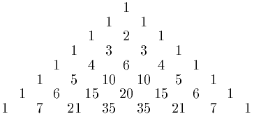

The second entry of the third row is $2=1+1$ and the second entry of the fifth row is $4=1+3$.

**(2 pts.)** Write a function `f_nt(n, k, alpha)` which computes the $k$-th entry of the $n$-th row of the $\alpha$-number triangle. Thus, using from the examples above, we would have

```
{r}
> f_nt(3, 2, 1)
[1] 2
> f_nt(5, 2, 1)
[1] 4
> f_nt(1, 1, 1)
[1] 1
> f_nt(8, 7, 1)
[1] 7
```

If $k<0$ or $k>n$ then the function should return $0$. You may assume when we test your code that $0 \le n\le 20$ and $0 \le \alpha \le 10$.

```r
f_nt = function(n, k, alpha) {
    ### BEGIN SOLUTION
    if (k < 0 | k > n) {
        0
    } else if (k == 1 | k == n) {
        alpha
    } else {
        f_nt(n - 1, k, alpha) + f_nt(n - 1, k - 1, alpha)
    }
    ### END SOLUTION
}
```

```r
for (n in 1:10)  {
    for (k in 1:(n+1)) {
        stopifnot(choose(n, k) == f_nt(n + 1, k + 1, 1))
    }
}
### BEGIN HIDDEN TESTS
for (n in 1:10)  {
    for (k in 1:(n+1)) {
        for (alpha in 1:5) {
            stopifnot(alpha * choose(n, k) == f_nt(n + 1, k + 1, alpha))
        }
    }
}
### END HIDDEN TESTS
```

**(4 pts.)** If $n$ is large then then your function `f_nt` will run very slowly, or even crash. Write a function `f_nt_memo(n, k, alpha)` which uses memoization to efficiently compute the anser for large $n$. We will test your function on values of $n$ ranging from 1 to 200, and $\alpha$ from 1 to 10. The memoization data structure has been allocated for you:

```r
memo = array(NA_integer_, dim = c(200, 200, 20)) # access using: memo[n, k, alpha]
```

```r
f_nt_memo = function(n, k, alpha) {
    ### BEGIN SOLUTION
    if (k < 0 | k > n) return(0)
    if (k == 1 | k == n) return(alpha)
    if (is.na(memo[n, k, alpha])) {
        memo[n, k, alpha] <<- f_nt_memo(n - 1, k, alpha) + f_nt_memo(n - 1, k - 1, alpha)
    }
    memo[n, k, alpha]
    ### END SOLUTION
}
```

```r
for (n in 1:15) {
    for (k in 1:n) {
        for (alpha in 1:10) {
            stopifnot(f_nt_memo(n, k, alpha) == f_nt(n, k, alpha))
            stopifnot(f_nt_memo(n, k, alpha) == alpha * choose(n - 1, k - 1))
        }
    }
}
stopifnot(near(f_nt_memo(150, 50, 13), 8.72242e+40, tol=1e41))

### BEGIN HIDDEN TESTS
for (n in 30:40)  {
    for (k in 1:(n+1)) {
        for (alpha in 5:8) {
            stopifnot(alpha * choose(n, k) == f_nt_memo(n + 1, k + 1, alpha))
        }
    }
}
stopifnot(memo[38, 35, 6] == 46620)
### END HIDDEN TESTS
```